# Getting Started with TERRA Workbench

David LeBauer

2018-10-31

# TERRA REF Workbench

The focus of this tutorial is to get you started with the workbench.

For more details, please see the NDS Labs workbench [User Documentation](https://nationaldataservice.atlassian.net/wiki/display/NDSC/User%27s+Guide).

1. Registration and Approval ([Documentation](https://nationaldataservice.atlassian.net/wiki/display/NDSC/User%27s+Guide#User'sGuide-Registrationandapproval))
- Sign up for an account at https://www.workbench.terraref.org
- Verification email will be sent - click link in the email
- log in to https://www.workbench.terraref.org
2. Orientation
- When you first log in, you will see the welcome page.

[figure not shown]

- Click the link to [add an application](https://www.workbench.terraref.org/#/store). This will redirect you to the [Application Catalog](https://www.workbench.terraref.org/#/store) where you will see a list of computing environments:

[figure not shown]

This is the Application Catalog (See also [Application Catalog](https://nationaldataservice.atlassian.net/wiki/display/NDSC/User%27s+Guide#User'sGuide-Applicationcatalog) documentation.)

Currently, the TERRA REF workbench provides the following development environments:

[output not shown]

It is important to note that the tutorials each assume that you are using a specific programming environment.

| Topic | folder | Description | Application |  |
| --- | --- | --- | --- | --- |
| Trait data | /traits | extracting plant and plot level summaries | Rstudio |  |
| Sensor Data | /sensors |  | pyClowder-netcdf and Rstudio-geospatial |  |
| pyClowder | coming soon | adding algorithms to pipeline | Cloud9 and JupyterLab |  |

## Launching An Application

[Full Documentation](https://nationaldataservice.atlassian.net/wiki/display/NDSC/User%27s+Guide#User'sGuide-Launchinganapplication)

## Application 1: the command line

Most of these applications allow you to use the basic command line tools.

We will start with the most simple application, the Docker command-line environment

1. on the docker application, click ‘add’

[figure not shown]

2. click ‘view’

[figure not shown]

3. This will bring you back to the Applications tab, where you will see the Docker Application. Click ‘Launch’

[figure not shown]

4. Then click the icon next to the application name to launch it

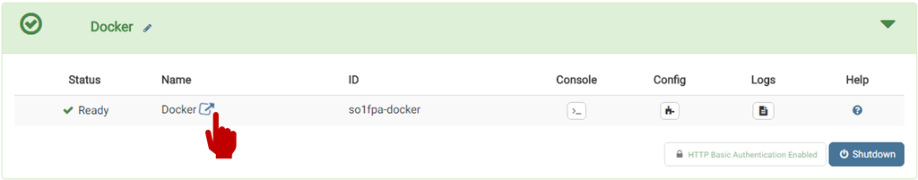

- you will be asked to enter a username and password. These are the same credentials used by the workbench

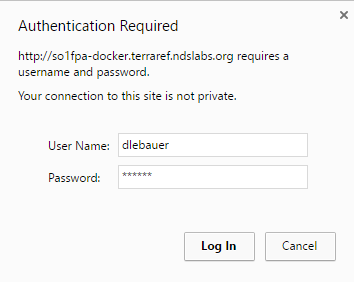

5. After successfully logging in, you will se a large black screen. This is a basic terminal.

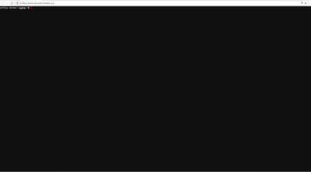

6. This is a way of looking at the file system contents. Type the following:

```bash
pwd                                   # your current directory
echo $HOME                            # your home directory
ls /data/terraref/sites               # where the sensor data lives
ls /data/terraref/sites/ua-mac/Level1 # directory containing Level 1 data from Maricopa
```

You should see something like this:

[figure not shown]

#### Directories

All of the application provide access to the same file systems. You will find two directories, one for your own work and one that contains files from the TERRA REF data.

- home directory is`/home/$USER/` where `$USER` is your workbench username.
- data directory is`/data/`. This directory is read-only, so you can’t modify the data

### Application 2: Rstudio Server

Now we are ready to get started! However, this command line tool is not particularly powerful.

Lets open an environment for using data in R

Create Application:

1. navigate back to the [Application Catalog](https://www.workbench.terraref.org/#/store)
2. Find the “RStudio Server” Application, click “Add”, “View”, “launch”, “open” as we did in the previous tutorial
3. Credentials
- You will again enter your workbench username and password
- Rstudio will pop up a second request for credentials. This time both the username and password are ‘rstudio’

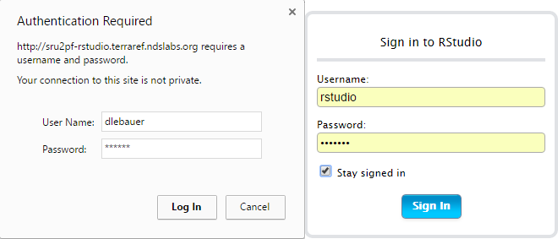

#### Clone the ‘Tutorials’ Directory

With the RStudio Application Open

1. Click File –> New Project

[figure not shown]

1. Click “Version Control”

[figure not shown]

1. Click “Git”
1. Type https://github.com/terraref/tutorials
- this is the GitHub repository full of tutorials
- Click “Create Project”

[figure not shown]

5. Now you should see a new ‘tutorials’ directory has been created in your home directory
- There are folders with plantCV, sensors, and traits.
  - We are interested in the traits folder
  - Note that other tutorials will not run in this Application
- Click the “traits” directory

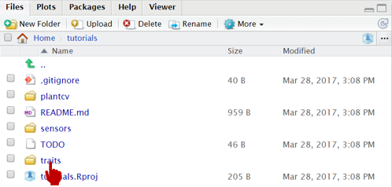

- Open the file “00-BETYdb-getting-started.Rmd”

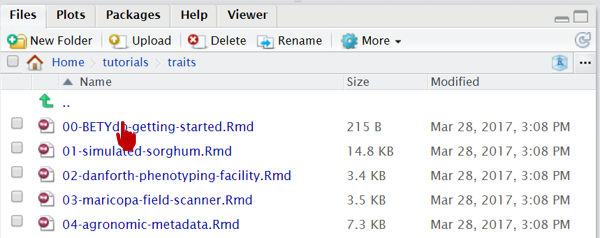

## Next Steps

Now, you are ready to move on to the first tutorial “Getting Started with BETYdb”.

You can also open applications for the sensor data tutorials (Rstudio-Geospatial and Jupyter/NetCDF) and plantCV (Jupyter/PlantCV) data.